# Project Proposal: Happiness Report’s top tier for multiple consecutive years

the fourth model training and pie chart of the factor importance

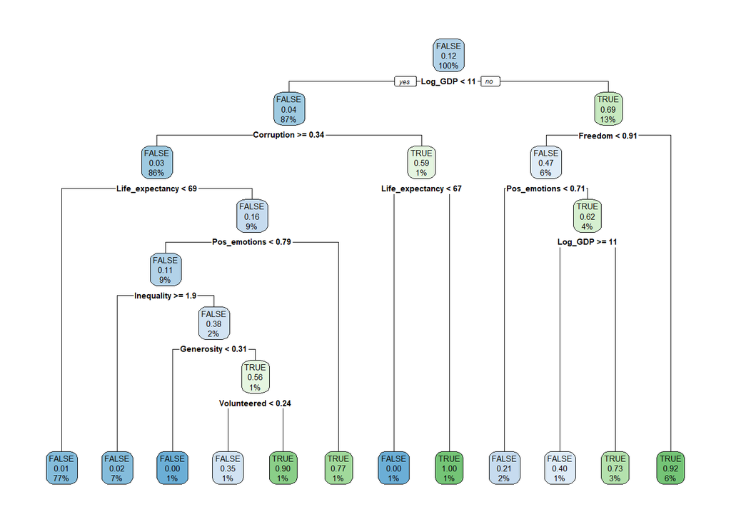

```
##         Log_GDP      Corruption Life_expectancy         Freedom  Social_support
##      196.216055      109.102401       55.365569       45.159611       41.566588
##      Generosity    Pos_emotions         Donated     Volunteered      Inequality
##       33.767854       32.153512       22.505093       22.019609       15.297242
##    Neg_emotions Helped_stranger
##        8.141424        6.413558
```

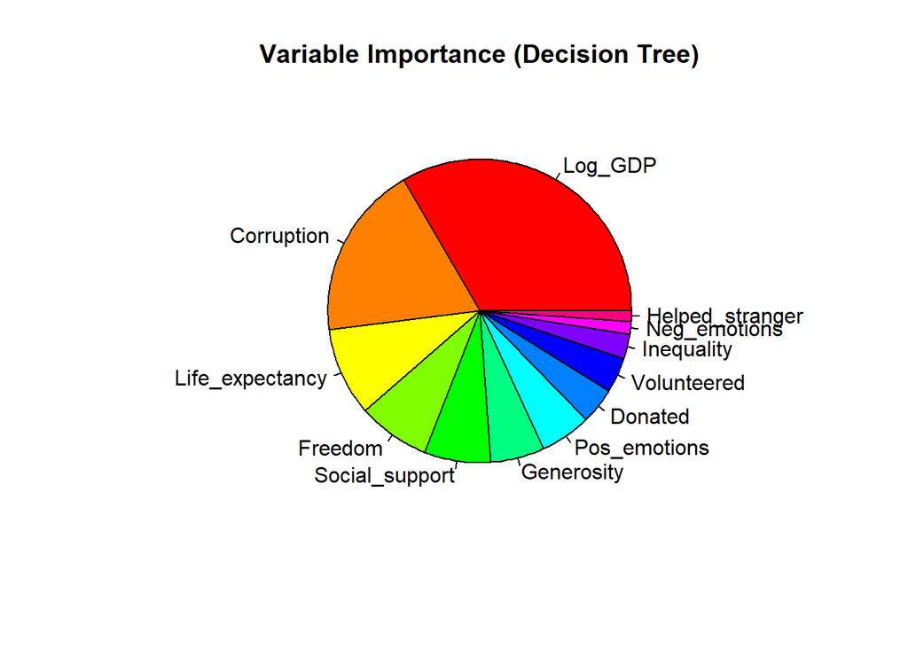

```
##          Actual
## Predicted FALSE TRUE
##     FALSE   366   15
##     TRUE     16   33
```

```
## Test Accuracy: 0.9279
```

*fifth model* the fifth model training and pie chart of the factor importance

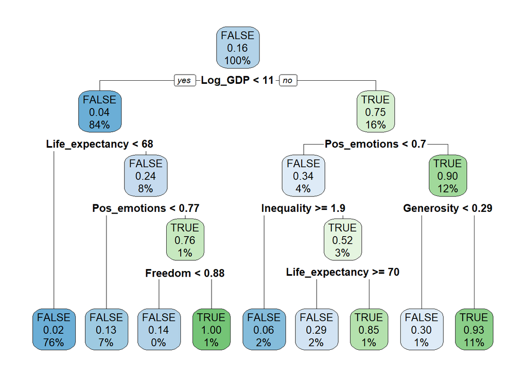

```
##         Log_GDP      Corruption Life_expectancy         Donated      Generosity
##      257.532671      133.384152      129.039658       63.544801       63.544801
##    Pos_emotions  Social_support         Freedom    Neg_emotions Helped_stranger
##       58.639131       54.083492       30.815309       13.025302       12.544757
##     Volunteered      Inequality
##        9.936165        8.066667
```

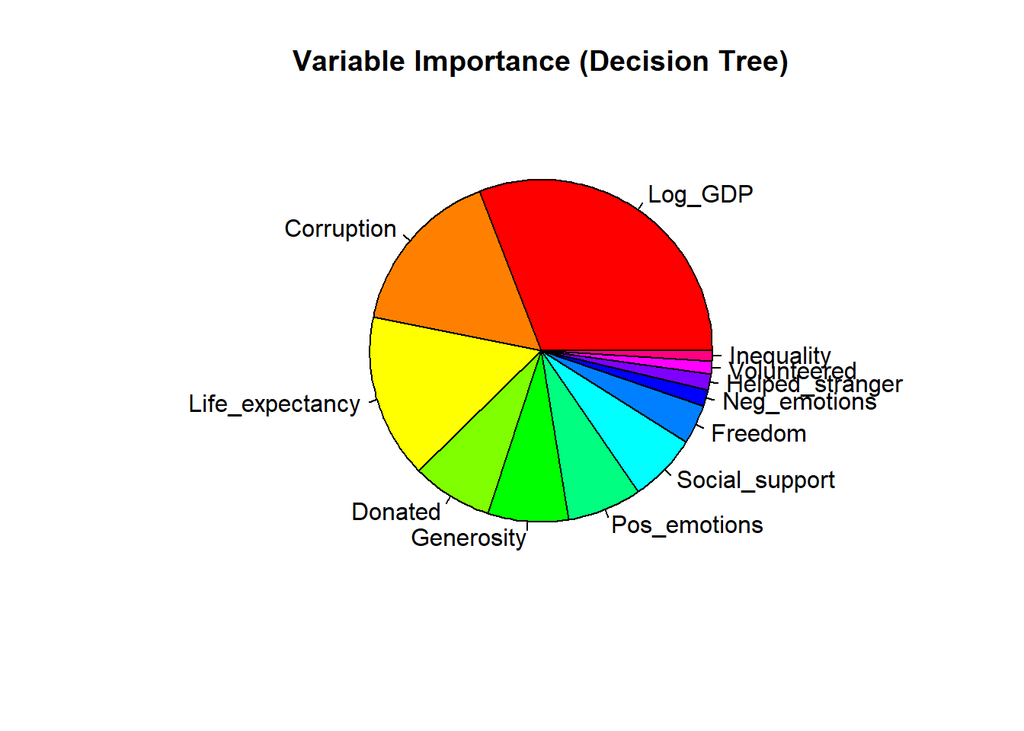

```
##          Actual
## Predicted FALSE TRUE
##     FALSE   356   23
##     TRUE      7   44
```

```
## Test Accuracy: 0.9302
```

*sixth model*

the sixth model training and pie chart of the factor importance

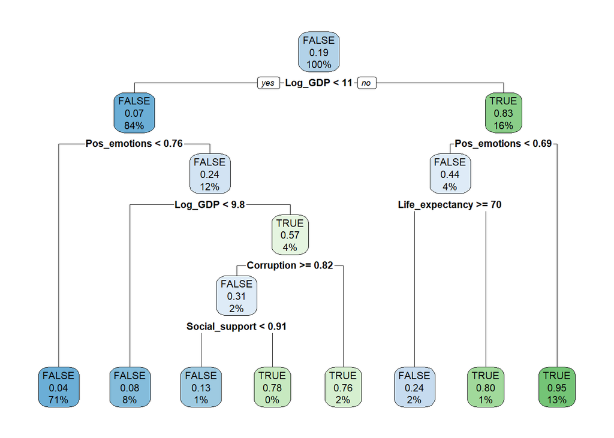

```
##         Log_GDP Life_expectancy      Corruption  Social_support         Donated
##     325.3280506     160.7360401     151.4283539      76.2235951      64.8625370
##      Generosity    Pos_emotions         Freedom    Neg_emotions      Inequality
##      64.8625370      48.8150385      14.2501997      11.2861828       3.3951615
##     Volunteered Helped_stranger
##       2.5536623       0.9177579
```

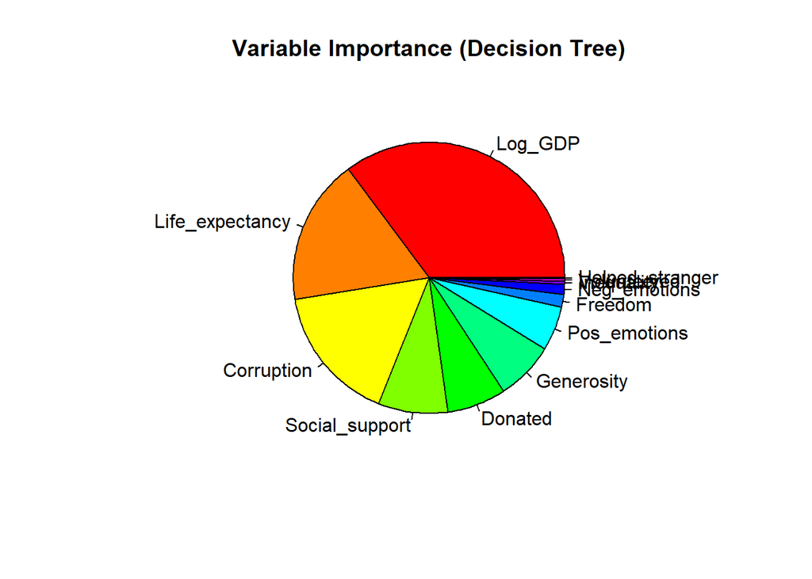

```
##          Actual
## Predicted FALSE TRUE
##     FALSE   336   30
##     TRUE      9   55
```

```
## Test Accuracy: 0.9093
```

```
##         Log_GDP      Corruption Life_expectancy         Freedom  Social_support
##      33.2013053      17.1838217      14.3119569       7.8809322       7.2436458
##      Generosity    Pos_emotions         Donated     Volunteered      Inequality
##       6.7022322       5.7554072       2.8796035       1.9744560       1.3312096
##    Neg_emotions Helped_stranger
##       0.8792259       0.6562038
```

```
##         Log_GDP      Corruption Life_expectancy         Freedom  Social_support
##       34.458924       16.919233       12.799623        8.342652        7.164928
##      Generosity    Pos_emotions         Donated     Volunteered      Inequality
##        6.745952        5.412008        2.769951        2.075671        1.470417
##    Neg_emotions Helped_stranger
##        1.091093        0.749548
```

**7 parameters**

new tree models based on 7 parameters

*first set*

*first model*

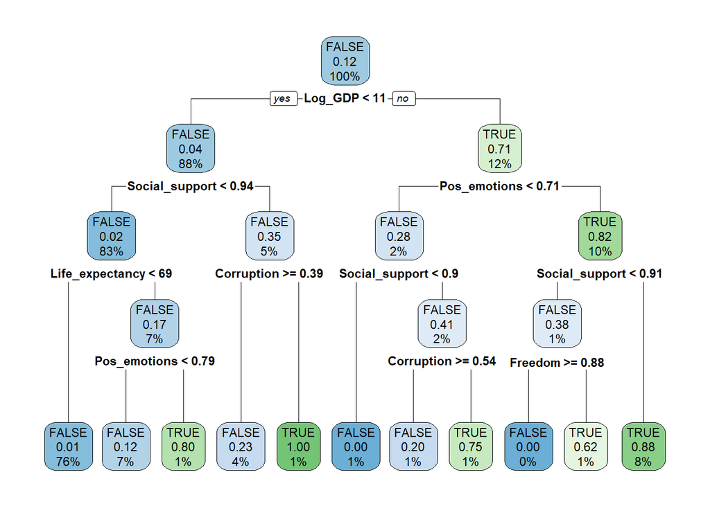

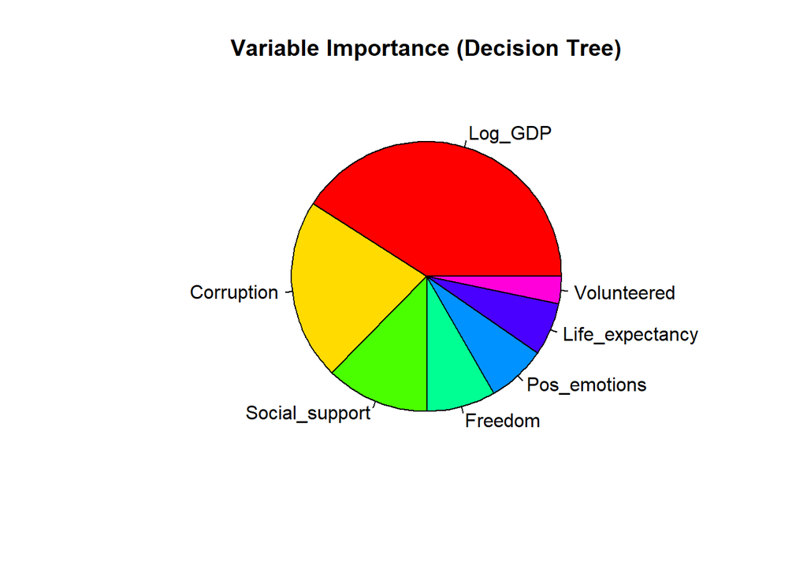

```
##          Actual
## Predicted FALSE TRUE
##     FALSE   333   11
##     TRUE     16   28
```

```
## Test Accuracy: 0.9304
```

*second model*